# Survey analysis

Jisu Kang

2024-11-26

```r
library(readr)
library(tidyverse)
library(forcats)
library(car)
library(reshape2)
```

## data transform

```r
banddata <- read_csv("Banddata.csv")
head(banddata)
```

```
## # A tibble: 6 × 26
##   Bandname Active Size  Period Position Officer Sex   Before_F1 Before_F2
##   <chr>     <dbl> <chr> <chr>  <chr>      <dbl> <chr>     <dbl>     <dbl>
## 1 BAB           1 20~30 1~2    K              0 F             4         5
## 2 BAB           1 ~20   0.5~1  K              0 F             4         4
## 3 Danpung       1 40~   1~2    V, K           1 F             4         5
## 4 BAB           1 20~30 0.5~1  V, G           0 M             3         2
## 5 BAB           1 20~30 2~     G              0 M             4         2
## 6 BAB           1 20~30 1~2    D              1 M             4         3
## # ℹ 17 more variables: Before_F3 <dbl>, Before_F4 <dbl>, F1_1 <dbl>,
## #   F1_2 <dbl>, F1_3 <dbl>, F1_4 <dbl>, F2_1 <dbl>, F2_2 <dbl>, F2_3 <dbl>,
## #   F3_1 <dbl>, F3_2 <dbl>, F3_3 <dbl>, F4_1 <dbl>, F4_2 <dbl>, F4_3 <dbl>,
## #   Satisfaction_1 <dbl>, Satisfaction_2 <dbl>
```

```r
transformed_data <- banddata %>%
  select(-F1_1,-F3_3) %>%
  mutate(
    Size = factor(Size),
    Sex = factor(Sex),
    Active = factor(Active), #factor형 추가
    Officer = factor(Officer)
    )

# Merging survey items by factor
transformed_data$F1_score <- rowMeans(transformed_data[, c("F1_2","F1_3", "F1_4")], na.rm = TRUE)
transformed_data$F2_score <- rowMeans(transformed_data[, c("F2_1", "F2_2", "F2_3")], na.rm = TRUE)
transformed_data$F3_score <- rowMeans(transformed_data[, c("F3_1","F3_2")], na.rm = TRUE)
transformed_data$F4_score <- rowMeans(transformed_data[, c("F4_1", "F4_2", "F4_3")], na.rm = TRUE)
transformed_data$overall_satisfaction <- rowMeans(transformed_data[, c( "Satisfaction_1", "Satisfaction_2")], na.rm = TRUE)
```

## 동아리 부원 유형의 분포

전체적인 분포를 알아보자.

```r
library(ggpubr)
```

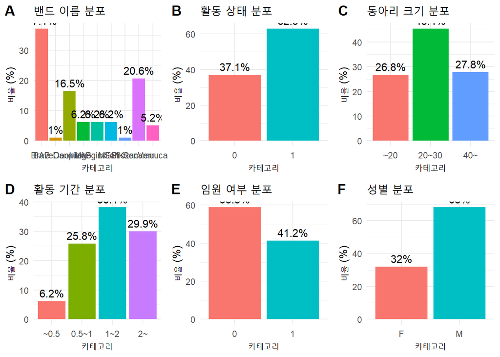

```r
title_map <- c(
  "Bandname" = "밴드 이름 분포",
  "Active" = "활동 상태 분포",
  "Size" = "동아리 크기 분포",
  "Period" = "활동 기간 분포",
  "Officer" = "임원 여부 분포",
  "Sex" = "성별 분포"
)

variables <- c("Bandname", "Active", "Size", "Period", "Officer", "Sex")

plots <- list()

for (var in variables) {
  counts <- table(transformed_data[[var]])
  df <- as.data.frame(counts)
  colnames(df) <- c("Category", "Count")
  df$Percentage <- (df$Count / sum(df$Count)) * 100
  p <- ggplot(df, aes(x = Category, y = Percentage, fill = Category)) +
    geom_bar(stat = "identity") +
    geom_text(aes(label = paste0(round(Percentage, 1), "%")), vjust = -0.5) +
    labs(
      title = title_map[[var]],
      x = "카테고리",
      y = "비율 (%)"
    ) +
    theme_minimal() +
    theme(legend.position = "none")

  plots[[var]] <- p
}

ggarrange(
  plots[["Bandname"]],
  plots[["Active"]],
  plots[["Size"]],
  plots[["Period"]],
  plots[["Officer"]],
  plots[["Sex"]],
  ncol = 3, nrow = 2,
  labels = c("A", "B", "C", "D", "E", "F")
)
```

## EDA

```r
# Histogram of Expectation & Satisfaction Level (Before EFA)
banddata2 <- banddata %>%
  rowwise() %>%
  mutate(
  F1_mean = mean(c(F1_2, F1_3, F1_4)),
  F2_mean = mean(c(F2_1, F2_2, F2_3)),
  F3_mean = mean(c(F3_1, F3_2)),
  F4_mean = mean(c(F4_1, F4_2, F4_3)),
  Satisfaction_mean = mean(c(Satisfaction_1, Satisfaction_2)),
  before_mean = mean(c(Before_F1, Before_F2, Before_F3, Before_F4))
  )
```

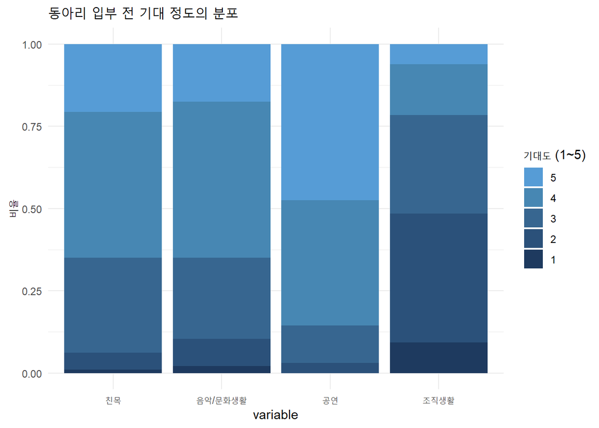

```r
## Expectation

Before <- banddata %>%
  select(Before_F1, Before_F2, Before_F3, Before_F4)

### 데이터를 long format으로 변환
Before_long <- Before %>%
  pivot_longer(cols = everything(), names_to = "variable", values_to = "value")


### 비율 계산
Before_summary <- Before_long %>%
  group_by(variable, value) %>%
  summarise(count = n(), .groups = "drop") %>%
  group_by(variable) %>%
  mutate(proportion = count / sum(count))


### 누적 막대 그래프 생성

custom_colors <- c("1" = "#ffcccc", # 연분홍
                   "2" = "#ff9999", # 옅은 분홍
                   "3" = "#ff6666", # 중간 분홍
                   "4" = "#ff3333", # 진한 분홍
                   "5" = "#cc0000") # 가장 진한 붉은색

custom_colors <- c("1" = "#1E3A5F",
                   "2" = "#2B517A",
                   "3" = "#376690",
                   "4" = "#4787B3",
                   "5" = "#569CD6")
ggplot(Before_summary, aes(x = variable, y = proportion, fill = fct_rev(factor(value)))) +
  geom_bar(stat = "identity", position = "fill")+
  labs(
    title = "동아리 입부 전 기대 정도의 분포",
    y = "비율",
    fill = "기대도 (1~5)"
  ) +
  theme_minimal() +
  scale_x_discrete(labels = c("Before_F1" = "친목",
                              "Before_F2" = "음악/문화생활",
                              "Before_F3" = "공연",
                              "Before_F4" = "조직생활")) +
  scale_fill_manual(values = custom_colors)
```

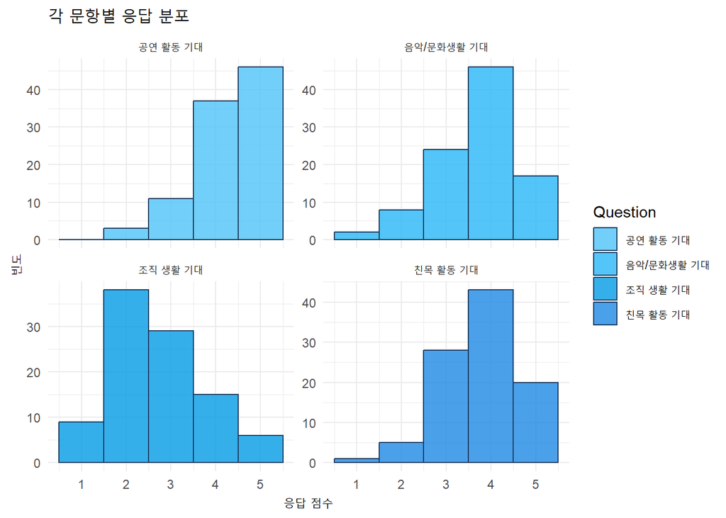

```r
# 데이터를 long format으로 변환
Before_long <- banddata %>%
  select(Before_F1, Before_F2, Before_F3, Before_F4) %>%
  pivot_longer(cols = everything(), names_to = "Question", values_to = "Response") %>%
  # 문항 이름을 한글로 변경
  mutate(Question = case_when(
    Question == "Before_F1" ~ "친목 활동 기대",
    Question == "Before_F2" ~ "음악/문화생활 기대",
    Question == "Before_F3" ~ "공연 활동 기대",
    Question == "Before_F4" ~ "조직 생활 기대"
  ))

# 히스토그램 병렬 표시
ggplot(Before_long, aes(x = Response, fill = Question)) +
  geom_histogram(binwidth = 1, alpha = 0.8, position = "dodge", colour = "#1E3A5F") +
  facet_wrap(~ Question, scales = "free_y") +
  labs(
    title = "각 문항별 응답 분포",
    x = "응답 점수",
    y = "빈도"
  ) +
  scale_fill_manual(values = c("#4FC3F7", "#29B6F6", "#039BE5", "#1E88E5")) + # 색상 설정
  theme_minimal()
```

```r
# 친목에 대한 기대도의 평균
mean(banddata2$Before_F1)
```

```
## [1] 3.783505
```

```r
# 음악/문화생활에 대한 기대도의 평균
mean(banddata2$Before_F2)
```

```
## [1] 3.701031
```

```r
# 공연에 대한 기대도의 평균
mean(banddata2$Before_F3)
```

```
## [1] 4.298969
```

```r
# 조직생활에 대한 기대도의 평균
mean(banddata2$Before_F4)
```

```
## [1] 2.701031
```

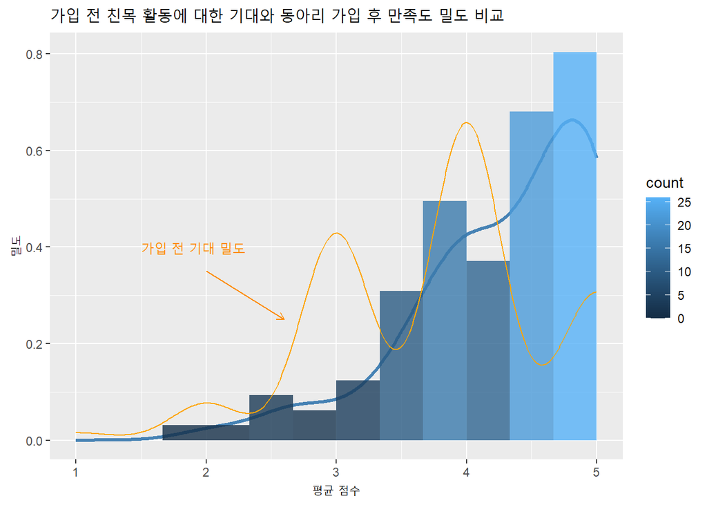

```r
banddata2 %>%
  select(F1_mean, Before_F1) %>%
  ggplot(aes(x = F1_mean)) +
  geom_density(colour = "#4682B4", size = 1.2) +
  geom_histogram(aes(y = ..density.., fill = ..count..), boundary = 1, alpha = 0.8, position = "identity",  binwidth=1/3) +
  geom_density(aes(x = Before_F1), alpha = 0.8, colour = "#FFA500")+
  geom_segment(aes(x = 2, y = 0.35, xend = 2.6, yend = 0.25),
               arrow = arrow(length = unit(0.2, "cm")), colour = "#FF8C00", size = 0.5)  +
  annotate("text", x = 1.5, y = 0.4, label = "가입 전 기대 밀도", size = 4, hjust = 0, colour = "#FF8C00")+
  labs(
    title = "가입 전 친목 활동에 대한 기대와 동아리 가입 후 만족도 밀도 비교",
    x = "평균 점수",
    y = "밀도"
  )
```

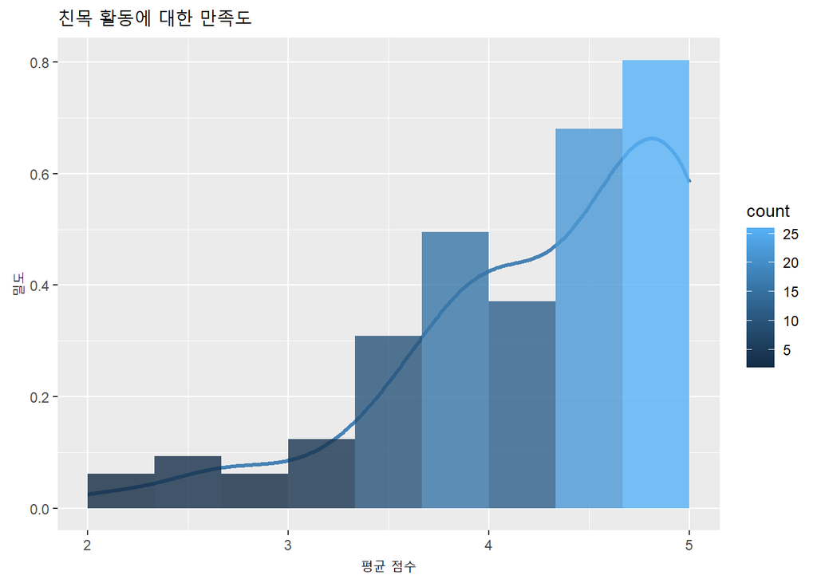

```r
banddata2 %>%
  select(F1_mean, Before_F1) %>%
  ggplot(aes(x = F1_mean)) +
  geom_density(colour = "#4682B4", size = 1.2) +
  geom_histogram(aes(y = ..density.., fill = ..count..), boundary = 1, alpha = 0.8, position = "identity",  binwidth=1/3) +
  labs(
    title = "친목 활동에 대한 만족도",
    x = "평균 점수",
    y = "밀도"
  )
```

```r
## 실제 친목에 대한 만족도의 평균
mean(banddata2$F1_mean)
```

```
## [1] 4.298969
```

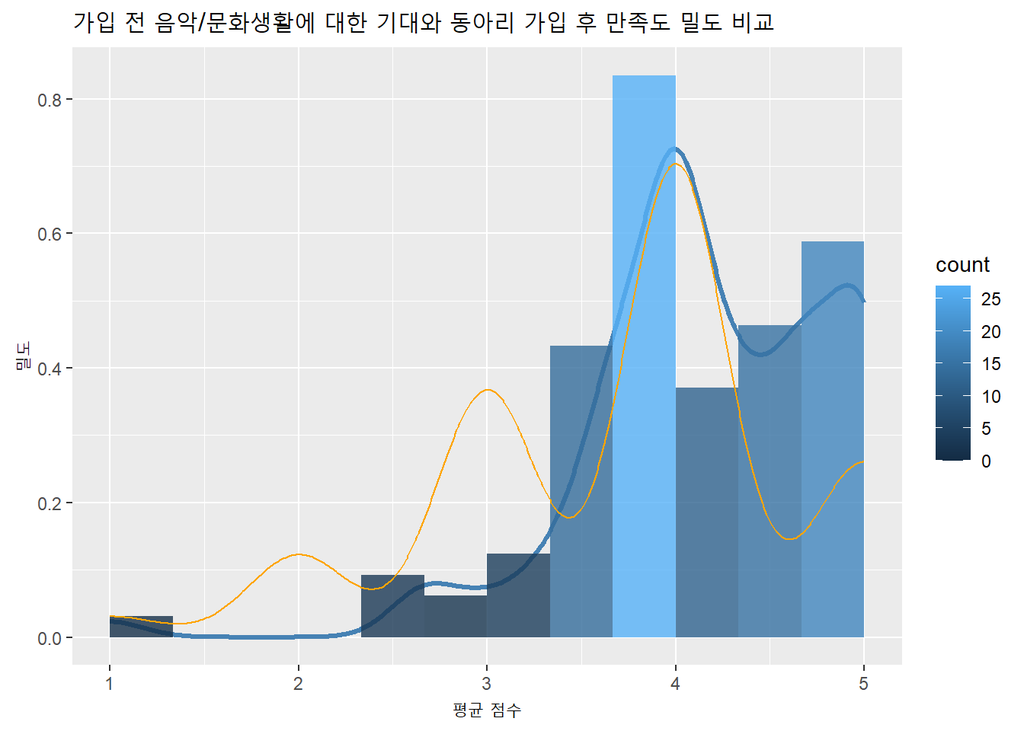

```r
banddata2 %>%
  select(F2_mean, Before_F2) %>%
  ggplot(aes(x = F2_mean)) +
  geom_density(colour = "#4682B4", size = 1.2) +
  geom_histogram(aes(y = ..density.., fill = ..count..), boundary = 1, alpha = 0.8, position = "identity",  binwidth=1/3) +
  geom_density(aes(x = Before_F2), alpha = 0.8, colour = "#FFA500")+
  labs(
    title = "가입 전 음악/문화생활에 대한 기대와 동아리 가입 후 만족도 밀도 비교",
    x = "평균 점수",
    y = "밀도"
  )
```

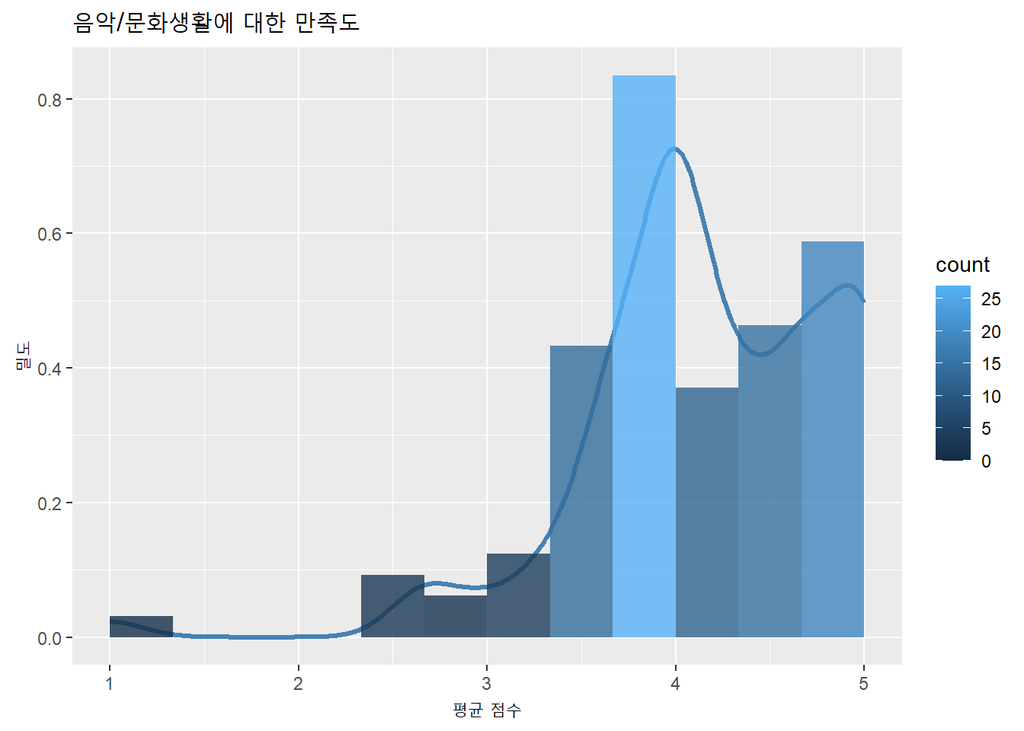

```r
banddata2 %>%
  select(F2_mean, Before_F2) %>%
  ggplot(aes(x = F2_mean)) +
  geom_density(colour = "#4682B4", size = 1.2) +
  geom_histogram(aes(y = ..density.., fill = ..count..), boundary = 1, alpha = 0.8, position = "identity",  binwidth=1/3) +
  labs(
    title = "음악/문화생활에 대한 만족도",
    x = "평균 점수",
    y = "밀도"
  )
```

```r
# 실제 음악/문화생활에 대한 만족도의 평균
mean(banddata2$F2_mean)
```

```
## [1] 4.171821
```

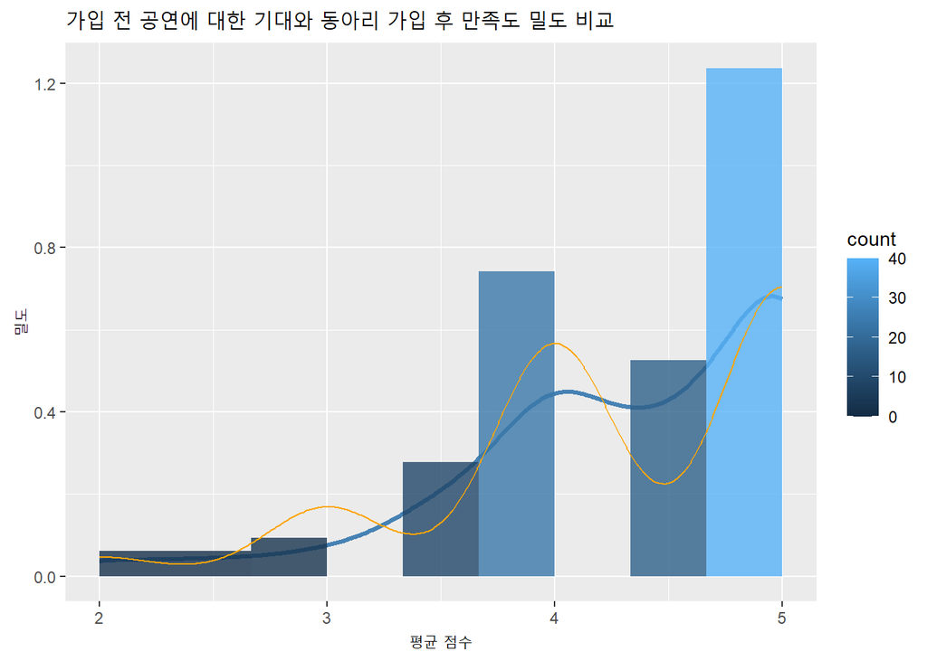

```r
banddata2 %>%
  select(F3_mean, Before_F3) %>%
  ggplot(aes(x = F3_mean)) +
  geom_density(colour = "#4682B4", size = 1.2) +
  geom_histogram(aes(y = ..density.., fill = ..count..), boundary = 1, alpha = 0.8, position = "identity",  binwidth=1/3) +
  geom_density(aes(x = Before_F3), alpha = 0.8, colour = "#FFA500") +
  labs(
    title = "가입 전 공연에 대한 기대와 동아리 가입 후 만족도 밀도 비교",
    x = "평균 점수",
    y = "밀도"
  )
```

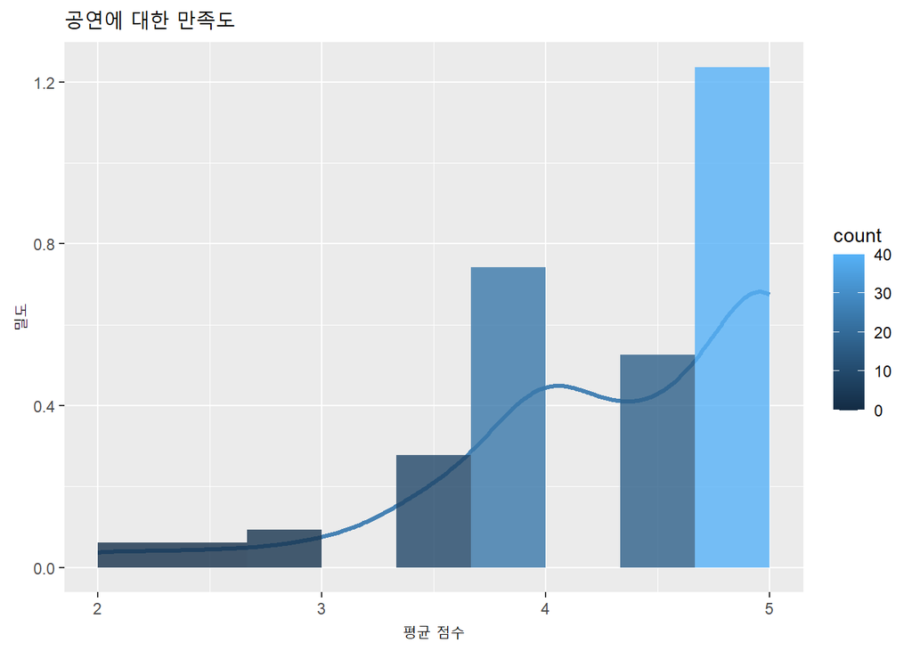

```r
banddata2 %>%
  select(F3_mean, Before_F3) %>%
  ggplot(aes(x = F3_mean)) +
  geom_density(colour = "#4682B4", size = 1.2) +
  geom_histogram(aes(y = ..density.., fill = ..count..), boundary = 1, alpha = 0.8, position = "identity",  binwidth=1/3) +
  labs(
    title = "공연에 대한 만족도",
    x = "평균 점수",
    y = "밀도"
  )
```

```r
# 실제 공연에 대한 만족도의 평균
mean(banddata2$F3_mean)
```

```
## [1] 4.350515
```

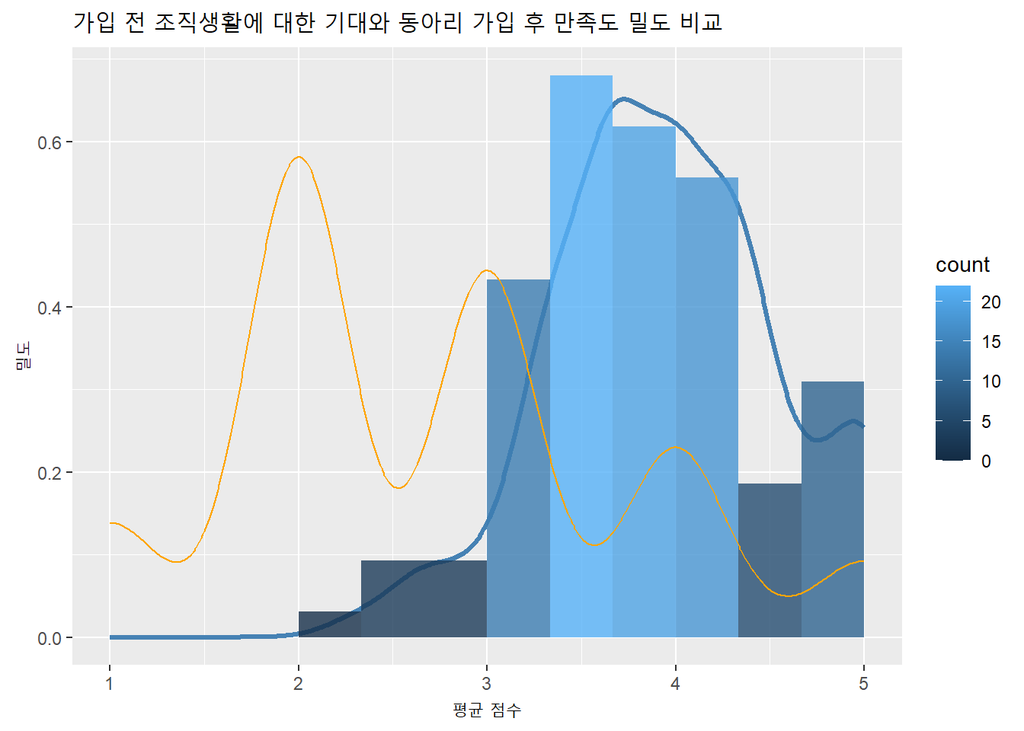

```r
banddata2 %>%
  select(F4_mean, Before_F4) %>%
  ggplot(aes(x = F4_mean)) +
  geom_density(colour = "#4682B4", size = 1.2) +
  geom_histogram(aes(y = ..density.., fill = ..count..), boundary = 1, alpha = 0.8, position = "identity",  binwidth=1/3) +
  geom_density(aes(x = Before_F4), alpha = 0.8, colour = "#FFA500")+
  labs(
    title = "가입 전 조직생활에 대한 기대와 동아리 가입 후 만족도 밀도 비교",
    x = "평균 점수",
    y = "밀도"
  )
```

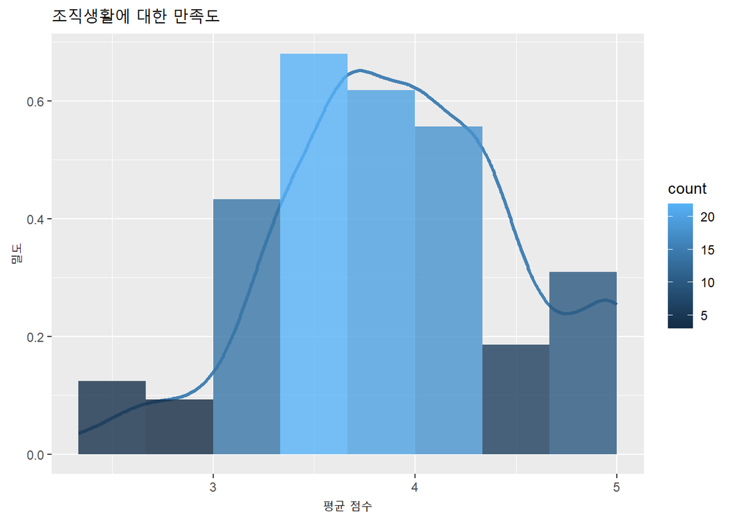

```r
banddata2 %>%
  select(F4_mean, Before_F4) %>%
  ggplot(aes(x = F4_mean)) +
  geom_density(colour = "#4682B4", size = 1.2) +
  geom_histogram(aes(y = ..density.., fill = ..count..), boundary = 1, alpha = 0.8, position = "identity",  binwidth=1/3) +
  labs(
    title = "조직생활에 대한 만족도",
    x = "평균 점수",
    y = "밀도"
  )
```

```r
# 실제 조직생활에 대한 만족도의 평균
mean(banddata2$F4_mean)
```

```
## [1] 3.945017
```

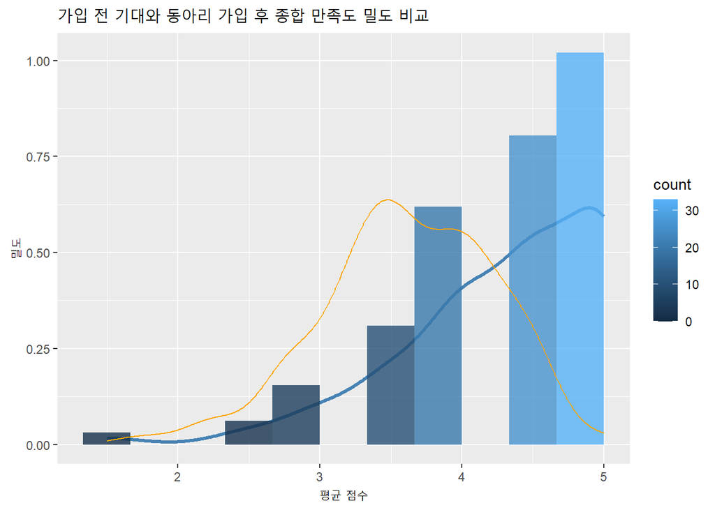

```r
banddata2 %>%
  select(Satisfaction_mean, before_mean) %>%
  ggplot(aes(x = Satisfaction_mean)) +
  geom_density(colour = "#4682B4", size = 1.2) +
  geom_histogram(aes(y = ..density.., fill = ..count..), boundary = 1, alpha = 0.8, position = "identity",  binwidth=1/3) +
  geom_density(aes(x = before_mean), alpha = 0.8, colour = "#FFA500") +
  labs(
    title = "가입 전 기대와 동아리 가입 후 종합 만족도 밀도 비교",
    x = "평균 점수",
    y = "밀도"
  )
```

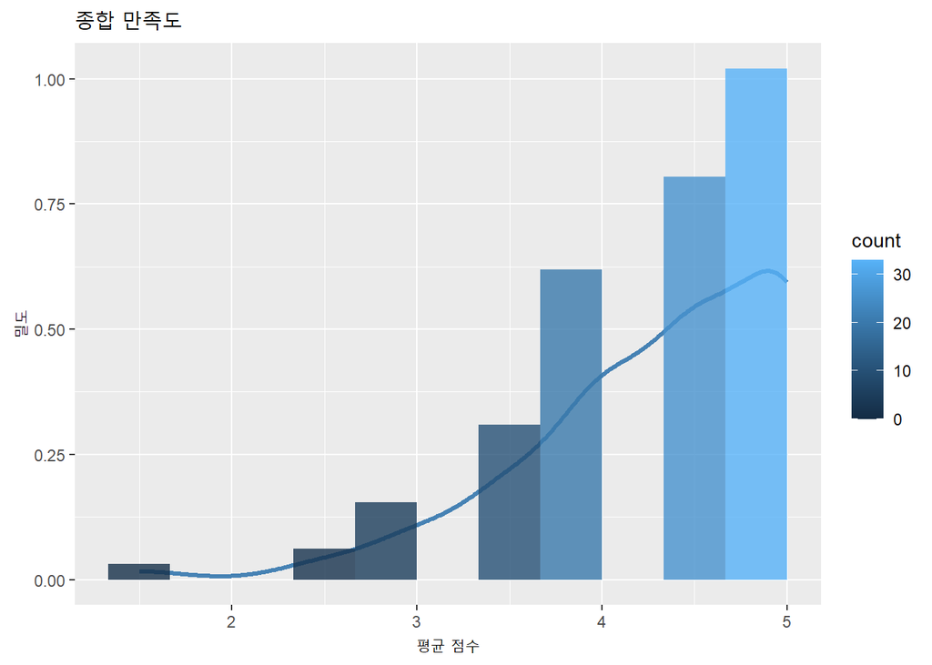

```r
banddata2 %>%
  select(Satisfaction_mean) %>%
  ggplot(aes(x = Satisfaction_mean)) +
  geom_density(colour = "#4682B4", size = 1.2) +
  geom_histogram(aes(y = ..density.., fill = ..count..), boundary = 1, alpha = 0.8, position = "identity",  binwidth=1/3) +
  labs(
    title = "종합 만족도",
    x = "평균 점수",
    y = "밀도"
  )
```

```r
# 종합 만족도의 평균
mean(banddata2$Satisfaction_mean)
```

```
## [1] 4.314433
```

## 활동 이전 기댓값과 만족도 사이의 상관계수

```r
reduced_data <- transformed_data[,c(8:11, 25:29)]
cor1<-cor(reduced_data)
cor_data <- melt(cor1)
colnames(cor_data) <- c("Var1", "Var2", "Correlation")

unique(cor_data$Var1)
```

```
## [1] Before_F1            Before_F2            Before_F3
## [4] Before_F4            F1_score             F2_score
## [7] F3_score             F4_score             overall_satisfaction
## 9 Levels: Before_F1 Before_F2 Before_F3 Before_F4 F1_score ... overall_satisfaction
```

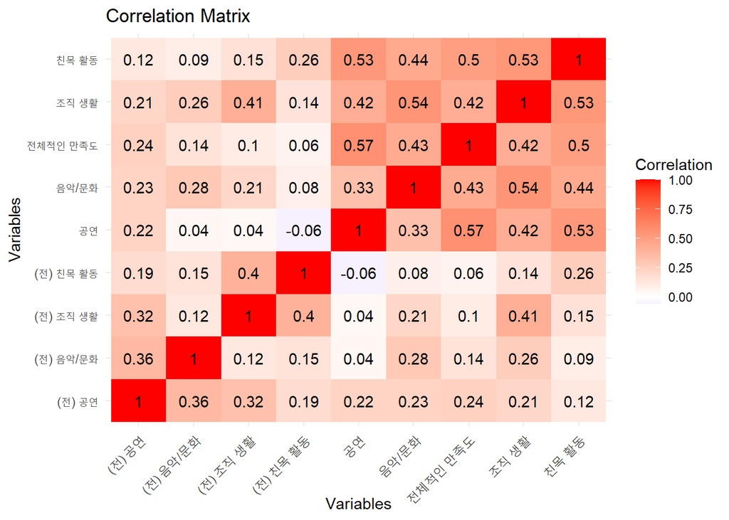

```r
variable_names <- c("Before_F1" = "(전) 친목 활동",
                    "Before_F2" = "(전) 음악/문화",
                    "Before_F3" = "(전) 공연",
                    "Before_F4" = "(전) 조직 생활",
                    "F1_score" = "친목 활동",
                    "F2_score" = "음악/문화",
                    "F3_score" = "공연",
                    "F4_score" = "조직 생활",
                    "overall_satisfaction" = "전체적인 만족도")

cor_data$Var1 <- variable_names[cor_data$Var1]
cor_data$Var2 <- variable_names[cor_data$Var2]

ggplot(cor_data, aes(x = Var1, y = Var2, fill = Correlation)) +
  geom_tile() +
  scale_fill_gradient2(low = "blue", mid = "white", high = "red", midpoint = 0) +
  geom_text(aes(label = round(Correlation, 2)), color = "black") +
  labs(title = "Correlation Matrix",
       x = "Variables",
       y = "Variables") +
  theme_minimal() +
  theme(axis.text.x = element_text(angle = 45, hjust = 1))
```

활동 이전 기댓값과 활동 이후 만족도 사이에 약한 상관관계가 존재했고, 활동 이후 만족도 사이에는 서로 강한 상관관계를 보였다. 활동 이전에 동아리 활동에 대해 기대한 정도가 이후의 만족도에 비해 큰 연관이 없으므로 이후의 요인분석에서는 활동 이전의 기댓값을 배제하고 탐색적 요인분석을 진행한다.

## 탐색적 요인분석(EFA)

동아리 활동 만족도 문항들에 대해 탐색적 요인분석을 진행한다.

```r
library(GPArotation)
library(psych)
F_score <- transformed_data[, 12:22]

cor_matrix <- cor(F_score)
print(cor_matrix)
```

```
##           F1_2      F1_3      F1_4      F2_1       F2_2      F2_3       F3_1
## F1_2 1.0000000 0.5509243 0.4858989 0.1582285 0.19368200 0.2573272 0.42821539
## F1_3 0.5509243 1.0000000 0.7210906 0.4109985 0.26986663 0.2898335 0.48988644
## F1_4 0.4858989 0.7210906 1.0000000 0.4628302 0.37218129 0.3786918 0.49746665
## F2_1 0.1582285 0.4109985 0.4628302 1.0000000 0.45772911 0.4633467 0.25786438
## F2_2 0.1936820 0.2698666 0.3721813 0.4577291 1.00000000 0.4162028 0.09440839
## F2_3 0.2573272 0.2898335 0.3786918 0.4633467 0.41620275 1.0000000 0.20778895
## F3_1 0.4282154 0.4898864 0.4974666 0.2578644 0.09440839 0.2077889 1.00000000
## F3_2 0.2146549 0.4238109 0.5145266 0.2996866 0.27732715 0.2505052 0.64578689
## F4_1 0.3776324 0.4531932 0.4768601 0.3733199 0.30041763 0.2512796 0.28095437
## F4_2 0.3377399 0.3019712 0.2801691 0.3591597 0.28167451 0.3891727 0.22061919
## F4_3 0.2916515 0.3474639 0.3474385 0.3407057 0.22890926 0.4393027 0.29648293
##           F3_2      F4_1      F4_2      F4_3
## F1_2 0.2146549 0.3776324 0.3377399 0.2916515
## F1_3 0.4238109 0.4531932 0.3019712 0.3474639
## F1_4 0.5145266 0.4768601 0.2801691 0.3474385
## F2_1 0.2996866 0.3733199 0.3591597 0.3407057
## F2_2 0.2773272 0.3004176 0.2816745 0.2289093
## F2_3 0.2505052 0.2512796 0.3891727 0.4393027
## F3_1 0.6457869 0.2809544 0.2206192 0.2964829
## F3_2 1.0000000 0.2523698 0.2611016 0.4389895
## F4_1 0.2523698 1.0000000 0.4624233 0.2766280
## F4_2 0.2611016 0.4624233 1.0000000 0.3983755
## F4_3 0.4389895 0.2766280 0.3983755 1.0000000
```

```r
# KMO 검사 (표본 적합성 테스트)
kmo_result <- KMO(F_score)
print(kmo_result)
```

```
## Kaiser-Meyer-Olkin factor adequacy
## Call: KMO(r = F_score)
## Overall MSA =  0.81
## MSA for each item =
## F1_2 F1_3 F1_4 F2_1 F2_2 F2_3 F3_1 F3_2 F4_1 F4_2 F4_3
## 0.77 0.86 0.85 0.84 0.79 0.84 0.74 0.71 0.88 0.83 0.84
```

```r
#Overall KMO(0.81) 및 개별 변수의 MSA 값이 모두 0.7 이상으로 나타났기 때문에, 데이터는 탐색적 요인분석(EFA)에 충분히 적합하다.

# Bartlett's Test (요인 분석 가능성 확인)
bartlett_result <- cortest.bartlett(cor_matrix, n = nrow(F_score))
print(bartlett_result)
```

```
## $chisq
## [1] 401.8872
##
## $p.value
## [1] 3.195374e-54
##
## $df
## [1] 55
```

```r
# p < 0.05이므로 변수들 간에 유의미한 상관관계가 있으며, 요인분석을 수행할 수 있다.

# 탐색적 요인 분석
efa_result <- fa(F_score, nfactors = 4, rotate = "varimax")
print(efa_result)
```

```
## Factor Analysis using method =  minres
## Call: fa(r = F_score, nfactors = 4, rotate = "varimax")
## Standardized loadings (pattern matrix) based upon correlation matrix
##       MR1  MR3  MR2  MR4   h2    u2 com
## F1_2 0.65 0.03 0.09 0.32 0.53 0.471 1.5
## F1_3 0.75 0.28 0.24 0.10 0.71 0.290 1.5
## F1_4 0.69 0.44 0.31 0.01 0.77 0.232 2.2
## F2_1 0.20 0.68 0.13 0.16 0.54 0.457 1.4
## F2_2 0.12 0.60 0.07 0.13 0.40 0.604 1.2
## F2_3 0.13 0.54 0.11 0.34 0.44 0.563 1.9
## F3_1 0.46 0.03 0.57 0.13 0.55 0.446 2.0
## F3_2 0.16 0.22 0.95 0.11 1.00 0.001 1.2
## F4_1 0.43 0.30 0.07 0.33 0.39 0.612 2.8
## F4_2 0.19 0.28 0.08 0.68 0.59 0.412 1.5
## F4_3 0.17 0.30 0.31 0.40 0.38 0.623 3.2
##
##                        MR1  MR3  MR2  MR4
## SS loadings           2.02 1.70 1.54 1.04
## Proportion Var        0.18 0.15 0.14 0.09
## Cumulative Var        0.18 0.34 0.48 0.57
## Proportion Explained  0.32 0.27 0.24 0.16
## Cumulative Proportion 0.32 0.59 0.84 1.00
##
## Mean item complexity =  1.9
## Test of the hypothesis that 4 factors are sufficient.
##
## df null model =  55  with the objective function =  4.39 with Chi Square =  401.89
## df of  the model are 17  and the objective function was  0.22
##
## The root mean square of the residuals (RMSR) is  0.03
## The df corrected root mean square of the residuals is  0.05
##
## The harmonic n.obs is  97 with the empirical chi square  9.16  with prob <  0.94
## The total n.obs was  97  with Likelihood Chi Square =  19.86  with prob <  0.28
##
## Tucker Lewis Index of factoring reliability =  0.972
## RMSEA index =  0.04  and the 90 % confidence intervals are  0 0.106
## BIC =  -57.91
## Fit based upon off diagonal values = 0.99
## Measures of factor score adequacy
##                                                    MR1  MR3 MR2  MR4
## Correlation of (regression) scores with factors   0.89 0.82   1 0.77
## Multiple R square of scores with factors          0.79 0.67   1 0.60
## Minimum correlation of possible factor scores     0.58 0.33   1 0.19
```

4개 요인이 데이터의 57%를 설명한다.

1. 요인 적재값(Factor Loadings)

MR1은 전체 데이터 분산의 18%, MR4는 9%를 설명.

4개 요인이 데이터의 57%를 설명함: 충분히 적합한 수준

2. 모델 적합도

RMSR (Root Mean Square of Residuals) = 0.03

df 보정된 RMSR = 0.05

Tucker Lewis Index (TLI) = 0.972

RMSEA = 0.04 (90% CI: 0 ~ 0.106): 적합도 우수

Chi-Square = 19.86, p-value = 0.28

p-value가 0.05 이상이므로, 데이터가 모델과 잘 맞는다고 할 수 있다.

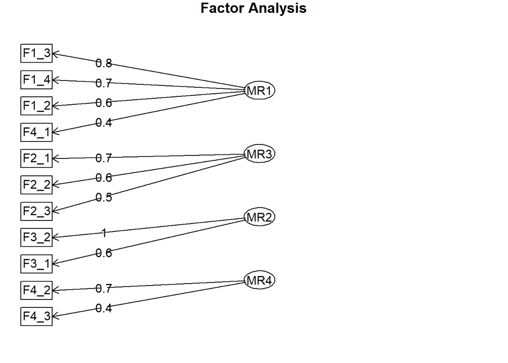

```r
# 요인 적재값 시각화
fa.diagram(efa_result) #책임감에 대한 문항이 친목과 관련이 있게 나왔다.
```

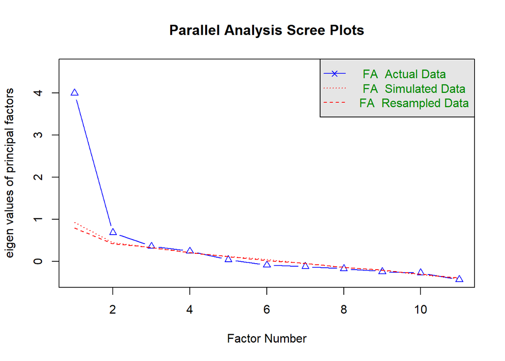

```
## Parallel analysis suggests that the number of factors =  2  and the number of components =  NA
```

```r
# Scree Plot
fa.parallel(F_score, fa = "fa") # 병렬 분석으로 요인 수 추천
```

최초에 설계한 설문지의 유형과 거의 유사하므로 요인별로 잘 나뉘어졌다 가정하고, 하나의 요인으로 묶인 문항의 만족도의 평균을 각 요인의 값으로 한다.

이미 설문지의 각 인자의 구성 문항이 어떤 특정한 개념(잠재변수)을 측정하도록 설계되었다면, 이미 해당 인자 구조를 전제한 상태이므로, 인자분석을 굳이 수행하지는 않고, 각 인자를 대표하는 점수를 계산하기 위해 단순 평균을 사용한다. 같은 인자에 속하는 문항들은 동일한 잠재변수를 측정한다고 가정되므로, 문항 값을 합치거나 평균을 내는 것이 충분히 그 인자를 대표할 수 있다.

단, 각 인자당 설정한 문항들에 대한 설문 설계가 올바르게 되었는지 확인하기 위해 **검증적 인자분석(CFA)**을 먼저 수행한다.

F1: 친구 관계 및 네트워크 형성. 총 4개 문항. F1_1 ~ F1_4 F2: 악기실력 및 음악적 소양. 총 3개 문항. F2_1 ~ F2_3 F3: 밴드 무대 경험. 총 3개 문항. F3_1 ~ F3_3 F4: 조직 생활과 임무 수행력 향상. 총 3개 문항. F4_1 ~ F4_3

크롬바흐 알파를 사용해 얻은 결과에 따라 F1_1, F3_3 항목은 빼고 분석을 진행한다.

아래 결과를 해석하자면, 일단 CFA 결과에서 첫 번째로 확인해야 할 부분은 모델 적합도이다. 주요 모델 적합도 지표로는 Chi-Sqaured Test of Model Fit, Comparative Fit Index(CFI), Tucker-Lewis Index(TLI), Root Mean Square Error of Approximation(RMSEA), Standardized Root Mean Square Residual(SRMR)로 총 5개인데, Chi-square은 큰 표본에서는 민감하므로 CFI, TLI, RMSEA, SRMR을 사용했다. 1) CFI >= 0.9: 적합도 양호 2) TLI >= 0.9: 적합도 양호 3) RMSEA <= 0.08 : 적합도 양호 4) SRMR <= 0.08: 적합도 양호 다음 조건을 모두 만족하므로, 우리가 설계했던 모델이 데이터를 잘 설명한다고 판단할 수 있다.

이 때, F1_1 항목과 F3_3 항목을 넣고 진행하면 모델 적합도가 양호하지 않다고 뜬다.

```r
# install.packages("lavaan")
library(lavaan)
cfa_model <- '
  Factor1 =~ F1_2 + F1_3 + F1_4
  Factor2 =~ F2_1 + F2_2 + F2_3
  Factor3 =~ F3_1 + F3_2
  Factor4 =~ F4_1 + F4_2 + F4_3
'
fit <- cfa(cfa_model, data = transformed_data)
summary(fit, fit.measures = TRUE, standardized = TRUE)
```

```
## lavaan 0.6-19 ended normally after 46 iterations
##
##   Estimator                                         ML
##   Optimization method                           NLMINB
##   Number of model parameters                        28
##
##   Number of observations                            97
##
## Model Test User Model:
##
##   Test statistic                                58.175
##   Degrees of freedom                                38
##   P-value (Chi-square)                           0.019
##
## Model Test Baseline Model:
##
##   Test statistic                               426.044
##   Degrees of freedom                                55
##   P-value                                        0.000
##
## User Model versus Baseline Model:
##
##   Comparative Fit Index (CFI)                    0.946
##   Tucker-Lewis Index (TLI)                       0.921
##
## Loglikelihood and Information Criteria:
##
##   Loglikelihood user model (H0)              -1089.613
##   Loglikelihood unrestricted model (H1)      -1060.525
##
##   Akaike (AIC)                                2235.225
##   Bayesian (BIC)                              2307.317
##   Sample-size adjusted Bayesian (SABIC)       2218.903
##
## Root Mean Square Error of Approximation:
##
##   RMSEA                                          0.074
##   90 Percent confidence interval - lower         0.031
##   90 Percent confidence interval - upper         0.110
##   P-value H_0: RMSEA <= 0.050                    0.151
```

[output cut: 44 more lines]

```
##    .F1_2              0.580    0.091    6.380    0.000    0.580    0.632
##    .F1_3              0.192    0.044    4.369    0.000    0.192    0.298
##    .F1_4              0.112    0.029    3.889    0.000    0.112    0.259
##    .F2_1              0.285    0.063    4.543    0.000    0.285    0.465
##    .F2_2              0.437    0.076    5.764    0.000    0.437    0.632
##    .F2_3              0.481    0.090    5.340    0.000    0.481    0.562
##    .F3_1              0.147    0.048    3.081    0.002    0.147    0.313
##    .F3_2              0.316    0.079    4.005    0.000    0.316    0.393
##    .F4_1              0.244    0.045    5.448    0.000    0.244    0.591
##    .F4_2              0.445    0.081    5.523    0.000    0.445    0.602
##    .F4_3              0.434    0.074    5.856    0.000    0.434    0.658
##     Factor1           0.337    0.108    3.112    0.002    1.000    1.000
##     Factor2           0.327    0.091    3.592    0.000    1.000    1.000
##     Factor3           0.322    0.077    4.192    0.000    1.000    1.000
##     Factor4           0.169    0.055    3.052    0.002    1.000    1.000
```

## 평균 재정의

```r
# Merging survey items by factor
transformed_data$F1_score <- rowMeans(transformed_data[, c("F1_2","F1_3", "F1_4", "F4_1")], na.rm = TRUE)
transformed_data$F2_score <- rowMeans(transformed_data[, c("F2_1", "F2_2", "F2_3")], na.rm = TRUE)
transformed_data$F3_score <- rowMeans(transformed_data[, c("F3_1","F3_2")], na.rm = TRUE)
transformed_data$F4_score <- rowMeans(transformed_data[, c("F4_2", "F4_3")], na.rm = TRUE)
transformed_data$overall_satisfaction <- rowMeans(transformed_data[, c( "Satisfaction_1", "Satisfaction_2")], na.rm = TRUE)
```

## EFA 이후 요인별 그래프

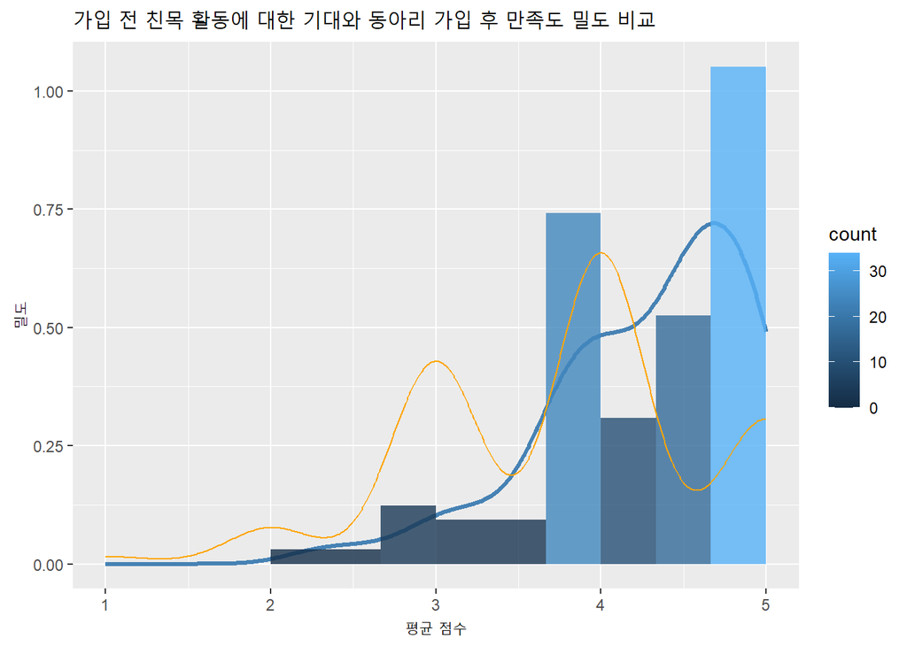

```r
# Histogram after moving a question after EFA

## 변경이 있는 첫번째 요소와 네번째 요소에 대해서 히스토그램 수정


banddata3 <- banddata %>%
  rowwise() %>%
  mutate(
  new_F1_mean = mean(c(F1_2, F1_3, F1_4, F4_1)),
  F2_mean = mean(c(F2_1, F2_2, F2_3)),
  F3_mean = mean(c(F3_1, F3_2)),
  new_F4_mean = mean(c(F4_2, F4_3)),
  Satisfaction_mean = mean(c(Satisfaction_1, Satisfaction_2))
  )


banddata3 %>%
  select(new_F1_mean, Before_F1) %>%
  ggplot(aes(x = new_F1_mean)) +
  geom_density(colour = "#4682B4", size = 1.2) +
  geom_histogram(aes(y = ..density.., fill = ..count..), boundary = 1, alpha = 0.8, position = "identity",  binwidth=1/3) +
  geom_density(aes(x = Before_F1), alpha = 0.8, colour = "#FFA500") +
  labs(
    title = "가입 전 친목 활동에 대한 기대와 동아리 가입 후 만족도 밀도 비교",
    x = "평균 점수",
    y = "밀도"
  )
```

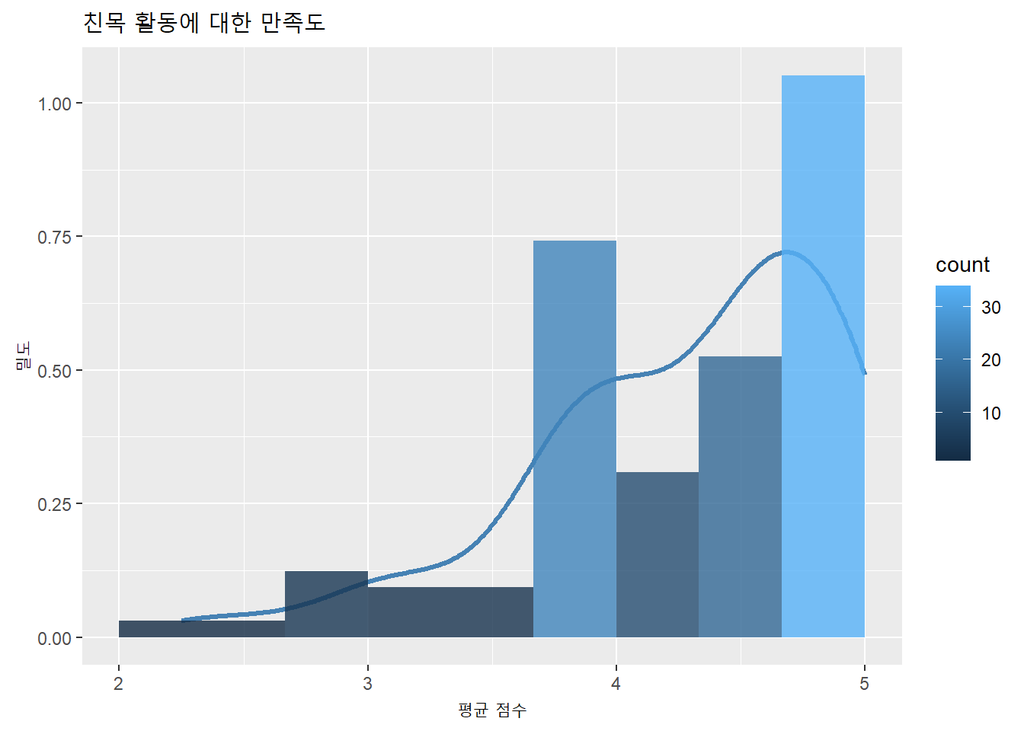

```r
banddata3 %>%
  select(new_F1_mean) %>%
  ggplot(aes(x = new_F1_mean)) +
  geom_density(colour = "#4682B4", size = 1.2) +
  geom_histogram(aes(y = ..density.., fill = ..count..), boundary = 1, alpha = 0.8, position = "identity",  binwidth=1/3) +
  labs(
    title = "친목 활동에 대한 만족도",
    x = "평균 점수",
    y = "밀도"
  )
```

```r
# 요인 1 만족도의 평균
mean(banddata3$new_F1_mean)
```

```
## [1] 4.268041
```

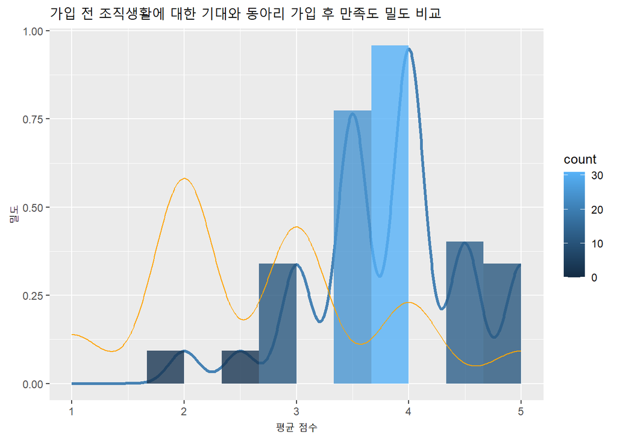

```r
banddata3 %>%
  select(new_F4_mean, Before_F4) %>%
  ggplot(aes(x = new_F4_mean)) +
  geom_density(colour = "#4682B4", size = 1.2) +
  geom_histogram(aes(y = ..density.., fill = ..count..), boundary = 1, alpha = 0.8, position = "identity",  binwidth=1/3) +
  geom_density(aes(x = Before_F4), alpha = 0.8, colour = "#FFA500")  +
  labs(
    title = "가입 전 조직생활에 대한 기대와 동아리 가입 후 만족도 밀도 비교",
    x = "평균 점수",
    y = "밀도"
  )
```

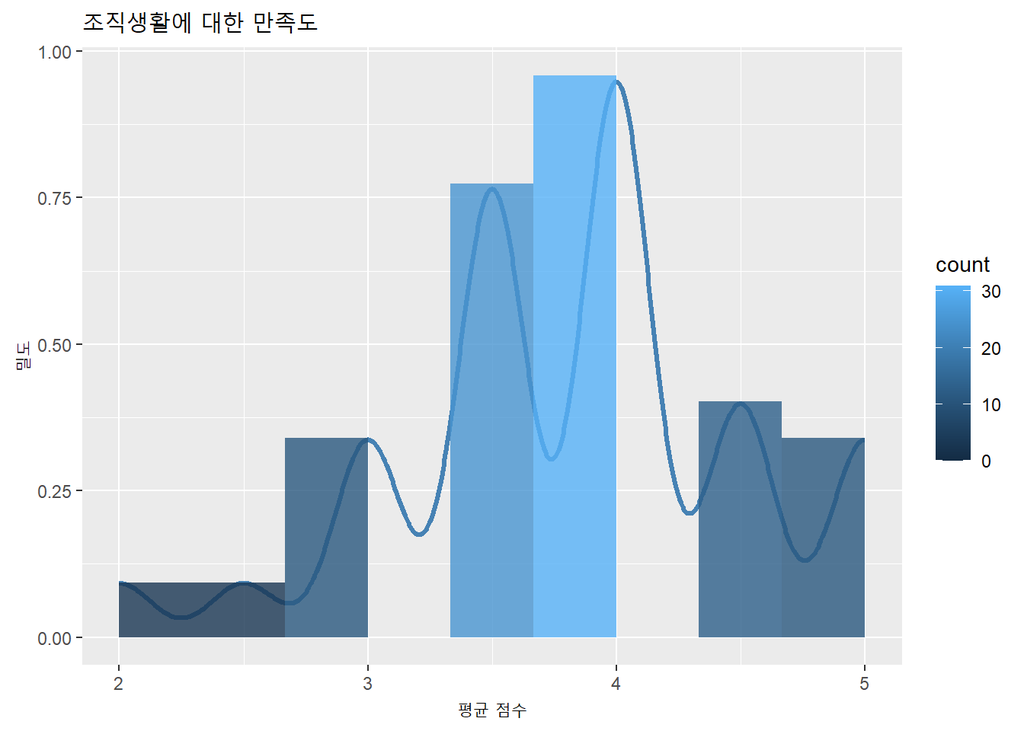

```r
banddata3 %>%
  select(new_F4_mean) %>%
  ggplot(aes(x = new_F4_mean)) +
  geom_density(colour = "#4682B4", size = 1.2) +
  geom_histogram(aes(y = ..density.., fill = ..count..), boundary = 1, alpha = 0.8, position = "identity",  binwidth=1/3) +
  labs(
    title = "조직생활에 대한 만족도",
    x = "평균 점수",
    y = "밀도"
  )
```

```r
# 요인 4 만족도의 평균
mean(banddata3$new_F4_mean)
```

```
## [1] 3.829897
```

## ANOVA

### 임원 활동의 유무에 따라

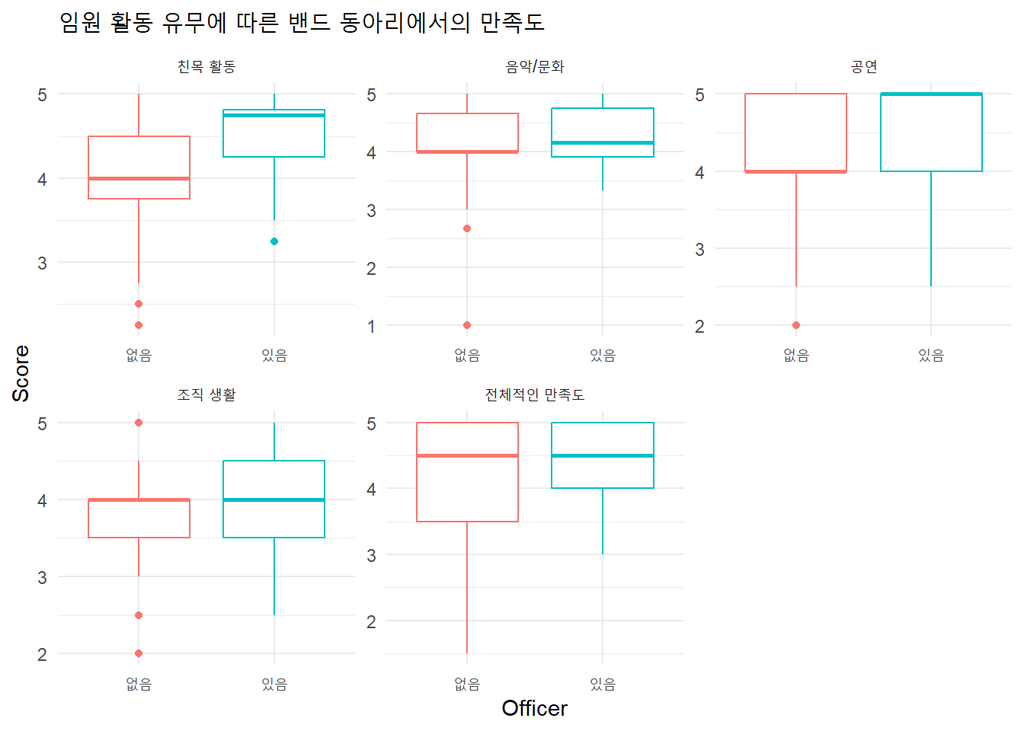

```r
long_data <- transformed_data %>%
  pivot_longer(cols = c(F1_score, F2_score, F3_score, F4_score, overall_satisfaction),
               names_to = "Metric",
               values_to = "Score")
levels(long_data$Officer) <- c("없음", "있음")
long_data$Metric <- as.factor(long_data$Metric)
levels(long_data$Metric) <- c("친목 활동", "음악/문화", "공연", "조직 생활", "전체적인 만족도")

ggplot(long_data, aes(x = Officer, y = Score, color = Officer)) +
  geom_boxplot() +
  facet_wrap(~ Metric, scales = "free") +
  labs(title = "임원 활동 유무에 따른 밴드 동아리에서의 만족도",
       x = "Officer",
       y = "Score") +
  theme_minimal()  +
  theme(legend.position = "none")
```

```r
# 등분산성 검정
leveneTest(F1_score ~ Officer, data = transformed_data)
```

```
## Levene's Test for Homogeneity of Variance (center = median)
##       Df F value  Pr(>F)
## group  1  4.8329 0.03035 *
##       95
## ---
## Signif. codes:  0 '***' 0.001 '**' 0.01 '*' 0.05 '.' 0.1 ' ' 1
```

```r
leveneTest(F2_score ~ Officer, data = transformed_data)
```

```
## Levene's Test for Homogeneity of Variance (center = median)
##       Df F value Pr(>F)
## group  1  0.2187 0.6411
##       95
```

```r
leveneTest(F3_score ~ Officer, data = transformed_data)
```

```
## Levene's Test for Homogeneity of Variance (center = median)
##       Df F value Pr(>F)
## group  1  2.2081 0.1406
##       95
```

```r
leveneTest(F4_score ~ Officer, data = transformed_data)
```

```
## Levene's Test for Homogeneity of Variance (center = median)
##       Df F value Pr(>F)
## group  1  1.8856 0.1729
##       95
```

```r
leveneTest(overall_satisfaction ~ Officer, data = transformed_data)
```

```
## Levene's Test for Homogeneity of Variance (center = median)
##       Df F value  Pr(>F)
## group  1  3.4845 0.06503 .
##       95
## ---
## Signif. codes:  0 '***' 0.001 '**' 0.01 '*' 0.05 '.' 0.1 ' ' 1
```

F1_score가 등분산성을 만족하지 못해 해당 항목만 Welch’s ANOVA를 사용하기로 한다.

```r
anova1 <- oneway.test(F1_score ~ Officer, data = transformed_data, var.equal = FALSE)
anova1
```

```
##
##  One-way analysis of means (not assuming equal variances)
##
## data:  F1_score and Officer
## F = 19.095, num df = 1.000, denom df = 94.885, p-value = 3.178e-05
```

```r
anova2 <- aov(F2_score ~ Officer, data = transformed_data)
summary(anova2)
```

```
##             Df Sum Sq Mean Sq F value Pr(>F)
## Officer      1   0.85  0.8464   1.872  0.174
## Residuals   95  42.96  0.4522
```

```r
anova3 <- aov(F3_score ~ Officer, data = transformed_data)
summary(anova3)
```

```
##             Df Sum Sq Mean Sq F value Pr(>F)
## Officer      1   3.06   3.059    6.18 0.0147 *
## Residuals   95  47.02   0.495
## ---
## Signif. codes:  0 '***' 0.001 '**' 0.01 '*' 0.05 '.' 0.1 ' ' 1
```

```r
anova4 <- aov(F4_score ~ Officer, data = transformed_data)
summary(anova4)
```

```
##             Df Sum Sq Mean Sq F value Pr(>F)
## Officer      1   1.97  1.9696   4.115 0.0453 *
## Residuals   95  45.47  0.4787
## ---
## Signif. codes:  0 '***' 0.001 '**' 0.01 '*' 0.05 '.' 0.1 ' ' 1
```

```r
anova5 <- aov(overall_satisfaction ~ Officer, data = transformed_data)
summary(anova5)
```

```
##             Df Sum Sq Mean Sq F value  Pr(>F)
## Officer      1   3.39   3.387   7.187 0.00866 **
## Residuals   95  44.77   0.471
## ---
## Signif. codes:  0 '***' 0.001 '**' 0.01 '*' 0.05 '.' 0.1 ' ' 1
```

```r
oneway.test(F1_score ~ Officer, data = transformed_data, var.equal = FALSE)
```

```
##
##  One-way analysis of means (not assuming equal variances)
##
## data:  F1_score and Officer
## F = 19.095, num df = 1.000, denom df = 94.885, p-value = 3.178e-05
```

```r
# 정규성 검정
by(transformed_data$F1_score, transformed_data$Officer, shapiro.test)
```

```
## transformed_data$Officer: 0
##
##  Shapiro-Wilk normality test
##
## data:  dd[x, ]
## W = 0.93459, p-value = 0.00417
##
## ------------------------------------------------------------
## transformed_data$Officer: 1
##
##  Shapiro-Wilk normality test
##
## data:  dd[x, ]
## W = 0.86172, p-value = 0.0001755
```

```r
shapiro.test(residuals(anova2))
```

```
##
##  Shapiro-Wilk normality test
##
## data:  residuals(anova2)
## W = 0.91297, p-value = 8.119e-06
```

```r
shapiro.test(residuals(anova3))
```

```
##
##  Shapiro-Wilk normality test
##
## data:  residuals(anova3)
## W = 0.88545, p-value = 4.331e-07
```

```r
shapiro.test(residuals(anova4))
```

```
##
##  Shapiro-Wilk normality test
##
## data:  residuals(anova4)
## W = 0.96908, p-value = 0.02173
```

```r
shapiro.test(residuals(anova5))
```

```
##
##  Shapiro-Wilk normality test
##
## data:  residuals(anova5)
## W = 0.9038, p-value = 2.905e-06
```

### 동아리 활동 기간에 따라

[figure not shown]

```r
levels(long_data$Period) <- c("6개월 미만", "6개월 이상 1년 미만", "1년 이상 2년 미만", "2년 이상")

ggplot(long_data, aes(x = Period, y = Score, color = Period)) +
  geom_boxplot() +
  facet_wrap(~ Metric, scales = "free") +
  labs(title = "동아리 활동 기간에 따른 밴드 동아리에서의 만족도",
       x = "Period",
       y = "Score") +
  theme_minimal()  +
  theme(legend.position = "none")
```

```r
# 등분산성 검정
leveneTest(F1_score ~ Period, data = transformed_data)
```

```
## Levene's Test for Homogeneity of Variance (center = median)
##       Df F value Pr(>F)
## group  3  0.2479 0.8626
##       93
```

```r
leveneTest(F2_score ~ Period, data = transformed_data)
```

```
## Levene's Test for Homogeneity of Variance (center = median)
##       Df F value Pr(>F)
## group  3  0.1504 0.9292
##       93
```

```r
leveneTest(F3_score ~ Period, data = transformed_data)
```

```
## Levene's Test for Homogeneity of Variance (center = median)
##       Df F value Pr(>F)
## group  3  0.7376 0.5322
##       93
```

```r
leveneTest(F4_score ~ Period, data = transformed_data)
```

```
## Levene's Test for Homogeneity of Variance (center = median)
##       Df F value Pr(>F)
## group  3  0.2873 0.8344
##       93
```

```r
leveneTest(overall_satisfaction ~ Period, data = transformed_data)
```

```
## Levene's Test for Homogeneity of Variance (center = median)
##       Df F value Pr(>F)
## group  3  1.5945  0.196
##       93
```

```r
anova1 <- aov(F1_score ~ Period, data = transformed_data)
summary(anova1)
```

```
##             Df Sum Sq Mean Sq F value Pr(>F)
## Period       3   3.88  1.2928   3.725  0.014 *
## Residuals   93  32.28  0.3471
## ---
## Signif. codes:  0 '***' 0.001 '**' 0.01 '*' 0.05 '.' 0.1 ' ' 1
```

```r
anova2 <- aov(F2_score ~ Period, data = transformed_data)
summary(anova2)
```

```
##             Df Sum Sq Mean Sq F value Pr(>F)
## Period       3   1.98  0.6599   1.467  0.229
## Residuals   93  41.82  0.4497
```

```r
anova3 <- aov(F3_score ~ Period, data = transformed_data)
summary(anova3)
```

```
##             Df Sum Sq Mean Sq F value Pr(>F)
## Period       3   5.18  1.7270   3.577 0.0169 *
## Residuals   93  44.90  0.4828
## ---
## Signif. codes:  0 '***' 0.001 '**' 0.01 '*' 0.05 '.' 0.1 ' ' 1
```

```r
anova4 <- aov(F4_score ~ Period, data = transformed_data)
summary(anova4)
```

```
##             Df Sum Sq Mean Sq F value Pr(>F)
## Period       3   1.48  0.4924   0.996  0.398
## Residuals   93  45.97  0.4943
```

```r
anova5 <- aov(overall_satisfaction ~ Period, data = transformed_data)
summary(anova5)
```

```
##             Df Sum Sq Mean Sq F value Pr(>F)
## Period       3   0.48  0.1614   0.315  0.815
## Residuals   93  47.68  0.5126
```

```r
# 정규성 검정
shapiro.test(residuals(anova3))
```

```
##
##  Shapiro-Wilk normality test
##
## data:  residuals(anova3)
## W = 0.87607, p-value = 1.752e-07
```

### 동아리 활동 인원에 따라

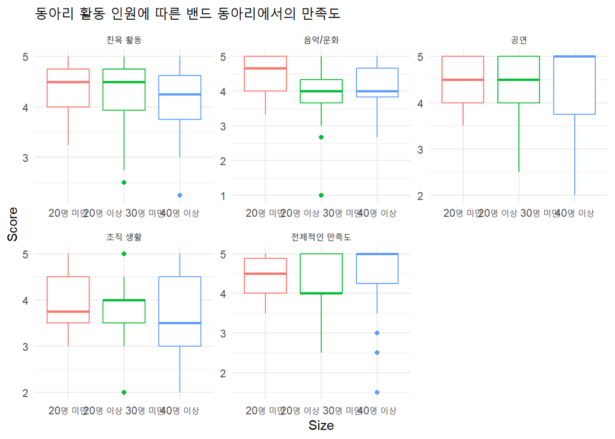

```r
levels(long_data$Size) <- c("20명 미만", "20명 이상 30명 미만", "40명 이상")

ggplot(long_data, aes(x = Size, y = Score, color = Size)) +
  geom_boxplot() +
  facet_wrap(~ Metric, scales = "free") +
  labs(title = "동아리 활동 인원에 따른 밴드 동아리에서의 만족도",
       x = "Size",
       y = "Score") +
  theme_minimal()  +
  theme(legend.position = "none")
```

```r
# 등분산성 검정
leveneTest(F1_score ~ Size, data = transformed_data)
```

```
## Levene's Test for Homogeneity of Variance (center = median)
##       Df F value Pr(>F)
## group  2  1.0101 0.3681
##       94
```

```r
leveneTest(F2_score ~ Size, data = transformed_data)
```

```
## Levene's Test for Homogeneity of Variance (center = median)
##       Df F value Pr(>F)
## group  2  0.2704 0.7637
##       94
```

```r
leveneTest(F3_score ~ Size, data = transformed_data)
```

```
## Levene's Test for Homogeneity of Variance (center = median)
##       Df F value Pr(>F)
## group  2  2.4884 0.0885 .
##       94
## ---
## Signif. codes:  0 '***' 0.001 '**' 0.01 '*' 0.05 '.' 0.1 ' ' 1
```

```r
leveneTest(F4_score ~ Size, data = transformed_data)
```

```
## Levene's Test for Homogeneity of Variance (center = median)
##       Df F value   Pr(>F)
## group  2  5.4027 0.006012 **
##       94
## ---
## Signif. codes:  0 '***' 0.001 '**' 0.01 '*' 0.05 '.' 0.1 ' ' 1
```

```r
leveneTest(overall_satisfaction ~ Size, data = transformed_data)
```

```
## Levene's Test for Homogeneity of Variance (center = median)
##       Df F value Pr(>F)
## group  2  1.8603 0.1613
##       94
```

```r
anova1 <- aov(F1_score ~ Size, data = transformed_data)
summary(anova1)
```

```
##             Df Sum Sq Mean Sq F value Pr(>F)
## Size         2   0.63  0.3144   0.832  0.438
## Residuals   94  35.53  0.3779
```

```r
anova2 <- aov(F2_score ~ Size, data = transformed_data)
summary(anova2)
```

```
##             Df Sum Sq Mean Sq F value Pr(>F)
## Size         2   2.99  1.4933   3.439 0.0362 *
## Residuals   94  40.82  0.4342
## ---
## Signif. codes:  0 '***' 0.001 '**' 0.01 '*' 0.05 '.' 0.1 ' ' 1
```

```r
anova3 <- aov(F3_score ~ Size, data = transformed_data)
summary(anova3)
```

```
##             Df Sum Sq Mean Sq F value Pr(>F)
## Size         2   0.67  0.3327   0.633  0.533
## Residuals   94  49.42  0.5257
```

```r
anova4 <- oneway.test(F4_score ~ Size, data = transformed_data, var.equal = FALSE)
anova4
```

```
##
##  One-way analysis of means (not assuming equal variances)
##
## data:  F4_score and Size
## F = 0.55898, num df = 2.000, denom df = 49.527, p-value = 0.5754
```

```r
anova5 <- aov(overall_satisfaction ~ Size, data = transformed_data)
summary(anova5)
```

```
##             Df Sum Sq Mean Sq F value Pr(>F)
## Size         2   1.04  0.5205   1.038  0.358
## Residuals   94  47.12  0.5013
```

```r
# 정규성 검정
shapiro.test(residuals(anova2))
```

```
##
##  Shapiro-Wilk normality test
##
## data:  residuals(anova2)
## W = 0.92141, p-value = 2.2e-05
```

### 성별에 따라

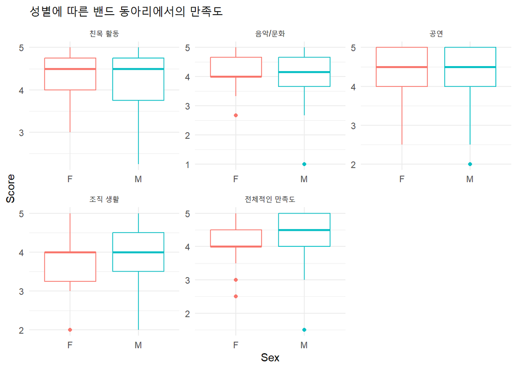

```r
levels(long_data$Sex) <- c("F", "M")

ggplot(long_data, aes(x = Sex, y = Score, color = Sex)) +
  geom_boxplot() +
  facet_wrap(~ Metric, scales = "free") +
  labs(title = "성별에 따른 밴드 동아리에서의 만족도",
       x = "Sex",
       y = "Score") +
  theme_minimal()  +
  theme(legend.position = "none")
```

```r
# 등분산성 검정
leveneTest(F1_score ~ Sex, data = transformed_data)
```

```
## Levene's Test for Homogeneity of Variance (center = median)
##       Df F value Pr(>F)
## group  1  1.0633 0.3051
##       95
```

```r
leveneTest(F2_score ~ Sex, data = transformed_data)
```

```
## Levene's Test for Homogeneity of Variance (center = median)
##       Df F value  Pr(>F)
## group  1  3.3698 0.06953 .
##       95
## ---
## Signif. codes:  0 '***' 0.001 '**' 0.01 '*' 0.05 '.' 0.1 ' ' 1
```

```r
leveneTest(F3_score ~ Sex, data = transformed_data)
```

```
## Levene's Test for Homogeneity of Variance (center = median)
##       Df F value Pr(>F)
## group  1  0.2446  0.622
##       95
```

```r
leveneTest(F4_score ~ Sex, data = transformed_data)
```

```
## Levene's Test for Homogeneity of Variance (center = median)
##       Df F value Pr(>F)
## group  1  0.0576 0.8108
##       95
```

```r
leveneTest(overall_satisfaction ~ Sex, data = transformed_data)
```

```
## Levene's Test for Homogeneity of Variance (center = median)
##       Df F value Pr(>F)
## group  1  0.7685 0.3829
##       95
```

```r
anova1 <- aov(F1_score ~ Sex, data = transformed_data)
summary(anova1)
```

```
##             Df Sum Sq Mean Sq F value Pr(>F)
## Sex          1   0.01  0.0092   0.024  0.877
## Residuals   95  36.15  0.3805
```

```r
anova2 <- aov(F2_score ~ Sex, data = transformed_data)
summary(anova2)
```

```
##             Df Sum Sq Mean Sq F value Pr(>F)
## Sex          1    0.0  0.0000       0  0.998
## Residuals   95   43.8  0.4611
```

```r
anova3 <- aov(F3_score ~ Sex, data = transformed_data)
summary(anova3)
```

```
##             Df Sum Sq Mean Sq F value Pr(>F)
## Sex          1   0.17  0.1651   0.314  0.576
## Residuals   95  49.92  0.5254
```

```r
anova4 <- aov(F4_score ~ Sex, data = transformed_data)
summary(anova4)
```

```
##             Df Sum Sq Mean Sq F value Pr(>F)
## Sex          1   0.35  0.3525   0.711  0.401
## Residuals   95  47.09  0.4957
```

```r
anova5 <- aov(overall_satisfaction ~ Sex, data = transformed_data)
summary(anova5)
```

```
##             Df Sum Sq Mean Sq F value Pr(>F)
## Sex          1   2.16  2.1584   4.458 0.0374 *
## Residuals   95  46.00  0.4842
## ---
## Signif. codes:  0 '***' 0.001 '**' 0.01 '*' 0.05 '.' 0.1 ' ' 1
```

```r
# 정규성 검정
shapiro.test(residuals(anova5))
```

```
##
##  Shapiro-Wilk normality test
##
## data:  residuals(anova5)
## W = 0.88318, p-value = 3.468e-07
```

### 활동 중인지에 따라

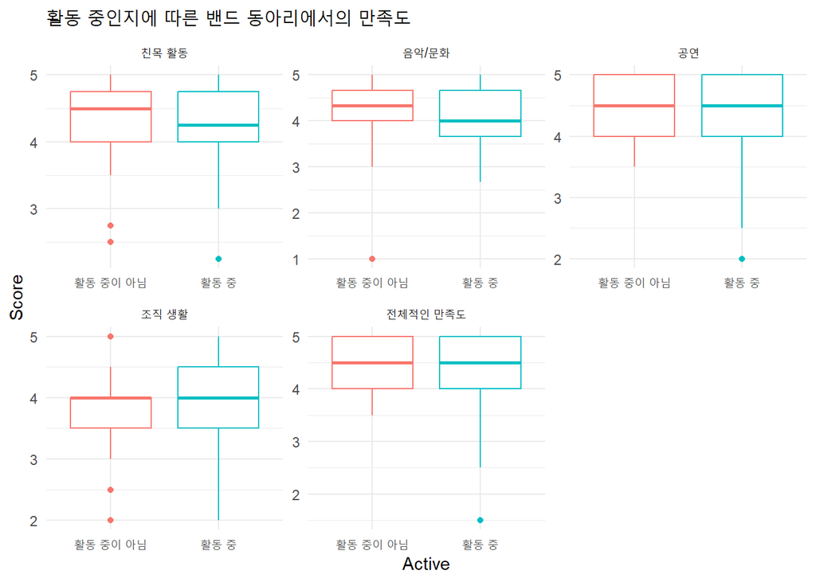

```r
levels(long_data$Active) <- c("활동 중이 아님", "활동 중")

ggplot(long_data, aes(x = Active, y = Score, color = Active)) +
  geom_boxplot() +
  facet_wrap(~ Metric, scales = "free") +
  labs(title = "활동 중인지에 따른 밴드 동아리에서의 만족도",
       x = "Active",
       y = "Score") +
  theme_minimal()  +
  theme(legend.position = "none")
```

```r
# 등분산성 검정
leveneTest(F1_score ~ Active, data = transformed_data)
```

```
## Levene's Test for Homogeneity of Variance (center = median)
##       Df F value Pr(>F)
## group  1  1.3663 0.2454
##       95
```

```r
leveneTest(F2_score ~ Active, data = transformed_data)
```

```
## Levene's Test for Homogeneity of Variance (center = median)
##       Df F value Pr(>F)
## group  1  0.2026 0.6536
##       95
```

```r
leveneTest(F3_score ~ Active, data = transformed_data)
```

```
## Levene's Test for Homogeneity of Variance (center = median)
##       Df F value  Pr(>F)
## group  1  6.8196 0.01048 *
##       95
## ---
## Signif. codes:  0 '***' 0.001 '**' 0.01 '*' 0.05 '.' 0.1 ' ' 1
```

```r
leveneTest(F4_score ~ Active, data = transformed_data)
```

```
## Levene's Test for Homogeneity of Variance (center = median)
##       Df F value Pr(>F)
## group  1  1.8095 0.1818
##       95
```

```r
leveneTest(overall_satisfaction ~ Active, data = transformed_data)
```

```
## Levene's Test for Homogeneity of Variance (center = median)
##       Df F value Pr(>F)
## group  1  1.0127 0.3168
##       95
```

```r
anova1 <- aov(F1_score ~ Active, data = transformed_data)
summary(anova1)
```

```
##             Df Sum Sq Mean Sq F value Pr(>F)
## Active       1   0.19  0.1949   0.515  0.475
## Residuals   95  35.96  0.3785
```

```r
anova2 <- aov(F2_score ~ Active, data = transformed_data)
summary(anova2)
```

```
##             Df Sum Sq Mean Sq F value Pr(>F)
## Active       1   0.76  0.7599   1.677  0.198
## Residuals   95  43.04  0.4531
```

```r
anova3 <- oneway.test(F3_score ~ Active, data = transformed_data, var.equal = FALSE)
anova3
```

```
##
##  One-way analysis of means (not assuming equal variances)
##
## data:  F3_score and Active
## F = 2.5906, num df = 1.000, denom df = 94.865, p-value = 0.1108
```

```r
anova4 <- aov(F4_score ~ Active, data = transformed_data)
summary(anova4)
```

```
##             Df Sum Sq Mean Sq F value Pr(>F)
## Active       1   0.37  0.3654   0.737  0.393
## Residuals   95  47.08  0.4956
```

```r
anova5 <- aov(overall_satisfaction ~ Active, data = transformed_data)
summary(anova5)
```

```
##             Df Sum Sq Mean Sq F value Pr(>F)
## Active       1   1.19  1.1854   2.397  0.125
## Residuals   95  46.97  0.4945
```

활동 유무에 따라서는 유의미한 만족도 차이가 나지 않는 것으로 보인다.

## Multiple linear regression

이제 문항 값을 평균내어 F*_score 열을 만들자.

```r
# Merging survey items by factor
transformed_data$F1_score <- rowMeans(transformed_data[, c("F1_2","F1_3", "F1_4")], na.rm = TRUE)
transformed_data$F2_score <- rowMeans(transformed_data[, c("F2_1", "F2_2", "F2_3")], na.rm = TRUE)
transformed_data$F3_score <- rowMeans(transformed_data[, c("F3_1","F3_2")], na.rm = TRUE)
transformed_data$F4_score <- rowMeans(transformed_data[, c("F4_1", "F4_2", "F4_3")], na.rm = TRUE)
transformed_data$overall_satisfaction <- rowMeans(transformed_data[, c( "Satisfaction_1", "Satisfaction_2")], na.rm = TRUE)
```

전체 만족도(반응 변수)를 예측하는 다중회귀분석을 진행한다.

```r
# Perform multiple linear regression
model_full <- lm(overall_satisfaction ~ F1_score + F2_score + F3_score + F4_score, data = transformed_data)
summary(model_full)
```

```
##
## Call:
## lm(formula = overall_satisfaction ~ F1_score + F2_score + F3_score +
##     F4_score, data = transformed_data)
##
## Residuals:
##     Min      1Q  Median      3Q     Max
## -1.4230 -0.3467  0.0724  0.3358  1.1903
##
## Coefficients:
##             Estimate Std. Error t value Pr(>|t|)
## (Intercept)  0.76745    0.46131   1.664 0.099585 .
## F1_score     0.17928    0.10760   1.666 0.099099 .
## F2_score     0.21184    0.10211   2.075 0.040821 *
## F3_score     0.37759    0.09426   4.006 0.000125 ***
## F4_score     0.06333    0.12425   0.510 0.611491
## ---
## Signif. codes:  0 '***' 0.001 '**' 0.01 '*' 0.05 '.' 0.1 ' ' 1
##
## Residual standard error: 0.5536 on 92 degrees of freedom
## Multiple R-squared:  0.4145, Adjusted R-squared:  0.389
## F-statistic: 16.28 on 4 and 92 DF,  p-value: 4.072e-10
```

## Evaluating model fit

Normal QQ plot follows normal distribution. Residual vs Fitted plot shows that residual is distributed randomly, but most of the data are placed on right(4 ~ 5).

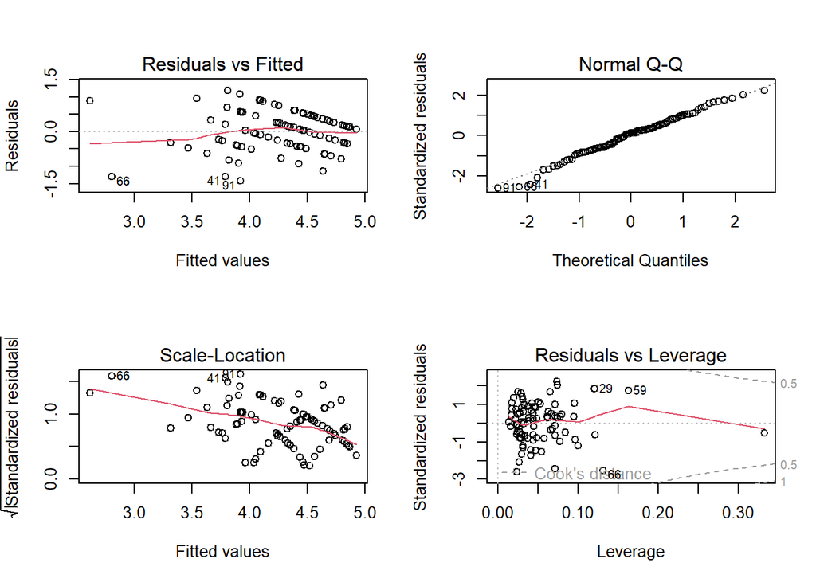

```r
# Residual plot
par(mfrow = c(2, 2))
plot(model_full)
```

```r
# Multicollinearity
library(car)
vif(model_full)
```

```
## F1_score F2_score F3_score F4_score
## 1.716520 1.490147 1.451742 1.719982
```

상관계수 > 0.7 : 강한 상관관계 -> 다중공선성 가능성 상관계수 < 0.7 : 약한 상관관계 -> 다중공선성 낮음

이 때, factor들 사이의 상관계수는 전부 0.7보다 작으므로, factor끼리의 상관관계는 적음을 알 수 있다.

```r
# correlation matrix
library(corrplot)
correlation_matrix <- cor(transformed_data[, c("F1_score", "F2_score", "F3_score", "F4_score")])
print(correlation_matrix)
```

```
##           F1_score  F2_score  F3_score  F4_score
## F1_score 1.0000000 0.4411987 0.5310739 0.5340685
## F2_score 0.4411987 1.0000000 0.3271888 0.5436666
## F3_score 0.5310739 0.3271888 1.0000000 0.4240203
## F4_score 0.5340685 0.5436666 0.4240203 1.0000000
```

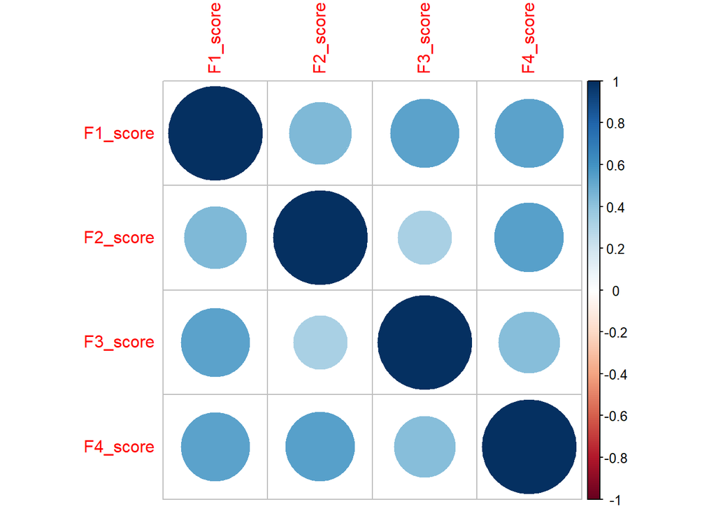

```r
corrplot(correlation_matrix, method = "circle")
```

## Multiple Regression(dividing sex)

```r
# male data
data_M <- transformed_data %>%
  filter(Sex == "M")

# Merging survey items by factor
data_M$F1_score <- rowMeans(data_M[, c("F1_2","F1_3", "F1_4")], na.rm = TRUE)
data_M$F2_score <- rowMeans(data_M[, c("F2_1", "F2_2", "F2_3")], na.rm = TRUE)
data_M$F3_score <- rowMeans(data_M[, c("F3_1","F3_2")], na.rm = TRUE)
data_M$F4_score <- rowMeans(data_M[, c("F4_1", "F4_2", "F4_3")], na.rm = TRUE)
data_M$overall_satisfaction <- rowMeans(data_M[, c( "Satisfaction_1", "Satisfaction_2")], na.rm = TRUE)
```

```r
# female data
data_F <- transformed_data %>%
  filter(Sex == "F")

# Merging survey items by factor
data_F$F1_score <- rowMeans(data_F[, c("F1_2","F1_3", "F1_4")], na.rm = TRUE)
data_F$F2_score <- rowMeans(data_F[, c("F2_1", "F2_2", "F2_3")], na.rm = TRUE)
data_F$F3_score <- rowMeans(data_F[, c("F3_1","F3_2")], na.rm = TRUE)
data_F$F4_score <- rowMeans(data_F[, c("F4_1", "F4_2", "F4_3")], na.rm = TRUE)
data_F$overall_satisfaction <- rowMeans(data_F[, c( "Satisfaction_1", "Satisfaction_2")], na.rm = TRUE)
```

```r
# male fit
model_M <- lm(overall_satisfaction ~ F1_score + F2_score + F3_score + F4_score, data = data_M)
summary(model_M)
```

```
##
## Call:
## lm(formula = overall_satisfaction ~ F1_score + F2_score + F3_score +
##     F4_score, data = data_M)
##
## Residuals:
##      Min       1Q   Median       3Q      Max
## -1.53453 -0.33980  0.05909  0.36380  1.09390
##
## Coefficients:
##             Estimate Std. Error t value Pr(>|t|)
## (Intercept)   1.3233     0.5238   2.526 0.014139 *
## F1_score      0.1350     0.1255   1.075 0.286488
## F2_score      0.1067     0.1176   0.907 0.368035
## F3_score      0.3807     0.1101   3.458 0.000996 ***
## F4_score      0.1012     0.1498   0.675 0.501949
## ---
## Signif. codes:  0 '***' 0.001 '**' 0.01 '*' 0.05 '.' 0.1 ' ' 1
##
## Residual standard error: 0.541 on 61 degrees of freedom
## Multiple R-squared:  0.3906, Adjusted R-squared:  0.3506
## F-statistic: 9.773 on 4 and 61 DF,  p-value: 3.56e-06
```

```r
# female fit
model_F <- lm(overall_satisfaction ~ F1_score + F2_score + F3_score + F4_score, data = data_F)
summary(model_F)
```

```
##
## Call:
## lm(formula = overall_satisfaction ~ F1_score + F2_score + F3_score +
##     F4_score, data = data_F)
##
## Residuals:
##     Min      1Q  Median      3Q     Max
## -0.9819 -0.2810 -0.0464  0.2323  0.9044
##
## Coefficients:
##              Estimate Std. Error t value Pr(>|t|)
## (Intercept) -1.399774   0.881752  -1.587  0.12449
## F1_score     0.298400   0.182452   1.635  0.11400
## F2_score     0.627694   0.190463   3.296  0.00284 **
## F3_score     0.370406   0.167424   2.212  0.03593 *
## F4_score     0.001326   0.206876   0.006  0.99494
## ---
## Signif. codes:  0 '***' 0.001 '**' 0.01 '*' 0.05 '.' 0.1 ' ' 1
##
## Residual standard error: 0.4984 on 26 degrees of freedom
## Multiple R-squared:  0.6135, Adjusted R-squared:  0.554
## F-statistic: 10.32 on 4 and 26 DF,  p-value: 3.858e-05
```

## Multiple Regression(dividing size)

```r
# ~20 data
data_under20 <- transformed_data %>%
  filter(Size == "~20")

# Merging survey items by factor
data_under20$F1_score <- rowMeans(data_under20[, c("F1_2","F1_3", "F1_4")], na.rm = TRUE)
data_under20$F2_score <- rowMeans(data_under20[, c("F2_1", "F2_2", "F2_3")], na.rm = TRUE)
data_under20$F3_score <- rowMeans(data_under20[, c("F3_1","F3_2")], na.rm = TRUE)
data_under20$F4_score <- rowMeans(data_under20[, c("F4_1", "F4_2", "F4_3")], na.rm = TRUE)
data_under20$overall_satisfaction <- rowMeans(data_under20[, c( "Satisfaction_1", "Satisfaction_2")], na.rm = TRUE)
```

```r
# 20~30 data
data_20to30 <- transformed_data %>%
  filter(Size == "20~30")

# Merging survey items by factor
data_20to30$F1_score <- rowMeans(data_20to30[, c("F1_2","F1_3", "F1_4")], na.rm = TRUE)
data_20to30$F2_score <- rowMeans(data_20to30[, c("F2_1", "F2_2", "F2_3")], na.rm = TRUE)
data_20to30$F3_score <- rowMeans(data_20to30[, c("F3_1","F3_2")], na.rm = TRUE)
data_20to30$F4_score <- rowMeans(data_20to30[, c("F4_1", "F4_2", "F4_3")], na.rm = TRUE)
data_20to30$overall_satisfaction <- rowMeans(data_20to30[, c( "Satisfaction_1", "Satisfaction_2")], na.rm = TRUE)
```

```r
# 40~ data
data_over40 <- transformed_data %>%
  filter(Size == "40~")

# Merging survey items by factor
data_over40$F1_score <- rowMeans(data_over40[, c("F1_2","F1_3", "F1_4")], na.rm = TRUE)
data_over40$F2_score <- rowMeans(data_over40[, c("F2_1", "F2_2", "F2_3")], na.rm = TRUE)
data_over40$F3_score <- rowMeans(data_over40[, c("F3_1","F3_2")], na.rm = TRUE)
data_over40$F4_score <- rowMeans(data_over40[, c("F4_1", "F4_2", "F4_3")], na.rm = TRUE)
data_over40$overall_satisfaction <- rowMeans(data_over40[, c( "Satisfaction_1", "Satisfaction_2")], na.rm = TRUE)
```

```r
# under20 fit
model_under20 <- lm(overall_satisfaction ~ F1_score + F2_score + F3_score + F4_score, data = data_under20)
summary(model_under20)
```

```
##
## Call:
## lm(formula = overall_satisfaction ~ F1_score + F2_score + F3_score +
##     F4_score, data = data_under20)
##
## Residuals:
##     Min      1Q  Median      3Q     Max
## -0.8095 -0.1804  0.0552  0.2401  0.8441
##
## Coefficients:
##             Estimate Std. Error t value Pr(>|t|)
## (Intercept)  2.13852    0.97823   2.186   0.0403 *
## F1_score     0.31449    0.17140   1.835   0.0807 .
## F2_score    -0.13098    0.19168  -0.683   0.5019
## F3_score     0.37695    0.17893   2.107   0.0474 *
## F4_score    -0.03739    0.16996  -0.220   0.8280
## ---
## Signif. codes:  0 '***' 0.001 '**' 0.01 '*' 0.05 '.' 0.1 ' ' 1
##
## Residual standard error: 0.4193 on 21 degrees of freedom
## Multiple R-squared:  0.2849, Adjusted R-squared:  0.1487
## F-statistic: 2.092 on 4 and 21 DF,  p-value: 0.118
```

```r
# 20to30 fit
model_20to30 <- lm(overall_satisfaction ~ F1_score + F2_score + F3_score + F4_score, data = data_20to30)
summary(model_20to30)
```

```
##
## Call:
## lm(formula = overall_satisfaction ~ F1_score + F2_score + F3_score +
##     F4_score, data = data_20to30)
##
## Residuals:
##     Min      1Q  Median      3Q     Max
## -1.3469 -0.3287 -0.0202  0.3256  1.1097
##
## Coefficients:
##             Estimate Std. Error t value Pr(>|t|)
## (Intercept)  0.69033    0.83517   0.827  0.41351
## F1_score     0.12769    0.15216   0.839  0.40649
## F2_score     0.20735    0.15574   1.331  0.19078
## F3_score     0.49473    0.16039   3.085  0.00374 **
## F4_score    -0.01524    0.23276  -0.065  0.94812
## ---
## Signif. codes:  0 '***' 0.001 '**' 0.01 '*' 0.05 '.' 0.1 ' ' 1
##
## Residual standard error: 0.5619 on 39 degrees of freedom
## Multiple R-squared:  0.3573, Adjusted R-squared:  0.2914
## F-statistic: 5.421 on 4 and 39 DF,  p-value: 0.001436
```

```r
# over40 fit
model_over40 <- lm(overall_satisfaction ~ F1_score + F2_score + F3_score + F4_score, data = data_over40)
summary(model_over40)
```

```
##
## Call:
## lm(formula = overall_satisfaction ~ F1_score + F2_score + F3_score +
##     F4_score, data = data_over40)
##
## Residuals:
##      Min       1Q   Median       3Q      Max
## -1.21461 -0.36096 -0.00082  0.54476  0.96245
##
## Coefficients:
##             Estimate Std. Error t value Pr(>|t|)
## (Intercept) -0.07067    0.83067  -0.085   0.9330
## F1_score     0.05584    0.30898   0.181   0.8582
## F2_score     0.41949    0.25378   1.653   0.1125
## F3_score     0.35566    0.20046   1.774   0.0899 .
## F4_score     0.24996    0.23815   1.050   0.3053
## ---
## Signif. codes:  0 '***' 0.001 '**' 0.01 '*' 0.05 '.' 0.1 ' ' 1
##
## Residual standard error: 0.6389 on 22 degrees of freedom
## Multiple R-squared:  0.6061, Adjusted R-squared:  0.5345
## F-statistic: 8.463 on 4 and 22 DF,  p-value: 0.0002715
```